# College Finder App

## Usage Notes Document

Praveen Dua  
Data Scientist

## Why a College Finder App ?

### The problem

- There are more than 7000 colleges in U.S.
- It is difficult for high school students to find good target schools to apply to
- Even harder for parents, especially first generation immigrant parents, to engage

#### [This app](https://praveendua.shinyapps.io/shiny_project) allows students and parents to sit around the kitchen table and find

- how many colleges are accessible
- what is the tution cost
- where are they located, geographically
- click the link for more info on the colleges in the tool-tip

### Quickly come up with an initial working list of colleges to start the process

## Filter Criteria

### Which colleges can I go to - Where are they located - What is the cost ?

### Enter search criteria for colleges on the left sidebar panel

- enter the home state ( 2 letter state abbreviation, e.g : CA )
- enter a list of additional states of interest ( comma separated list of state abbreviations )
  - Example : MA, IL, FL
  - leave this box blank to include all states
- set the SAT slider to the target score accepted by colleges ( SAT math + verbal )
- set the desired tuition fee for
  - in-state tuition for home state
  - out-of-state tuition for other states
- select the desired program
- select the desired degree

## Entering college finder selection criteria : Example

- enter your selections on this left sidebar pane as shown below
- The data used for this app is obtained from the US Dept of Education site [here](https://collegescorecard.ed.gov/data/)

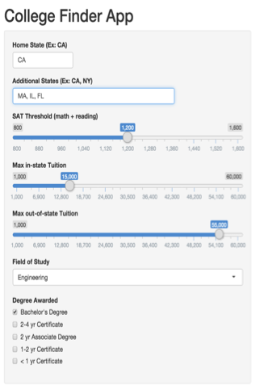

## Results shown on the main panel

- Number of colleges matching the selection criteria (if > 0, below 2 plots also shown)
- SAT -vs- Tuition plot : hover mouse on a point for name of college
- Locations of colleges : click on the school name in tool-tip for college info

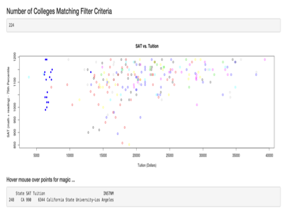

[figure not shown]